# Introduction_1_loadmetadata

Hangjia Zhao

2023-08-22

# Load library

```r
library(pgxRpi)
```

## `pgxLoader` function

This function loads various data from `Progenetix` database.

The parameters of this function used in this tutorial:

- `type` A string specifying output data type. Available options are “biosample”, “individual”, “variant” or “frequency”.
- `filters` Identifiers for cancer type, literature, cohorts, and age such as c(“NCIT:C7376”, “pgx:icdom-98353”, “PMID:22824167”, “pgx:cohort-TCGAcancers”, “age:>=P50Y”). For more information about filters, see the [documentation](https://docs.progenetix.org/beaconplus/#filters-filters-filtering-terms).
- `filterLogic` A string specifying logic for combining multiple filters when query metadata. Available options are “AND” and “OR”. Default is “AND”. An exception is filters associated with age that always use AND logic when combined with any other filter, even if filterLogic = “OR”, which affects other filters.
- `individual_id` Identifiers used in Progenetix database for identifying individuals.
- `biosample_id` Identifiers used in Progenetix database for identifying biosamples.
- `codematches` A logical value determining whether to exclude samples from child concepts of specified filters that belong to cancer type/tissue encoding system (NCIt, icdom/t, Uberon). If TRUE, retrieved samples only keep samples exactly encoded by specified filters. Do not use this parameter when `filters` include cancer-irrelevant filters such as PMID and cohort identifiers. Default is FALSE.
- `limit` Integer to specify the number of returned samples/individuals/coverage profiles for each filter. Default is 0 (return all).
- `skip` Integer to specify the number of skipped samples/individuals/coverage profiles for each filter. E.g. if skip = 2, limit=500, the first 2*500 =1000 profiles are skipped and the next 500 profiles are returned. Default is NULL (no skip).

# Retrieve meatdata of samples

## Relevant parameters

type, filters, filterLogic, individual_id, biosample_id, codematches, limit, skip

## Search by filters

The following query is to retrieve the metadata in Progenetix of all lung adenocarcinoma samples based on [NCIt code](https://ncit.nci.nih.gov):

```r
biosamples <- pgxLoader(type="biosample", filters = "NCIT:C3512")
# data looks like this
biosamples[c(1700:1705),]
```

```
#>        biosample_id group_id group_label   individual_id    callset_ids
#> 1700 pgxbs-kftvjjhx       NA          NA pgxind-kftx5fyd pgxcs-kftwjevi
#> 1701 pgxbs-kftvjjhz       NA          NA pgxind-kftx5fyf pgxcs-kftwjew0
#> 1702 pgxbs-kftvjji1       NA          NA pgxind-kftx5fyh pgxcs-kftwjewi
#> 1703 pgxbs-kftvjjn2       NA          NA pgxind-kftx5g4r pgxcs-kftwjg5r
#> 1704 pgxbs-kftvjjn4       NA          NA pgxind-kftx5g4t pgxcs-kftwjg6q
#> 1705 pgxbs-kftvjjn5       NA          NA pgxind-kftx5g4v pgxcs-kftwjg78
#>      external_references_id___PMID external_references_label___PMID
#> 1700                 PMID:26444668                               NA
#> 1701                 PMID:26444668                               NA
#> 1702                 PMID:26444668                               NA
#> 1703                 PMID:22961667                               NA
#> 1704                 PMID:22961667                               NA
#> 1705                 PMID:22961667                               NA
#>      external_references_id___arrayexpress
```

[output cut: 97 more lines]

The data contains many columns representing different aspects of sample information.

## Search by biosample id and individual id

```r
biosamples_2 <- pgxLoader(type="biosample", filters = "NCIT:C3512",codematches = TRUE,
                        biosample_id = c("pgxbs-kftva5zv","pgxbs-kftva5zw"),
                        individual_id = "pgxind-kftx26ml")
```

The result only contains samples with the specified filter NCIT:C3512, biosample id and individual id

```r
biosamples_2[biosamples_2$histological_diagnosis_id != "NCIT:C3512",c(1:5)]
```

```
#>        biosample_id group_id group_label   individual_id    callset_ids
#> 4643 pgxbs-kftva5zv       NA          NA pgxind-kftx266l pgxcs-kftvlijb
#> 4644 pgxbs-kftva5zw       NA          NA pgxind-kftx266n pgxcs-kftvlijs
#> 4645 pgxbs-kftva6d4       NA          NA pgxind-kftx26ml pgxcs-kftvlmn8
```

## Access a subset of samples

By default, it returns all related samples (limit=0). You can access a subset of them via the parameter `limit` and `skip`. For example, if you want to access the first 1000 samples , you can set `limit` = 1000, `skip` = 0.

```r
biosamples_3 <- pgxLoader(type="biosample", filters = "NCIT:C3512",skip=0, limit = 1000)
# Dimension: Number of samples * features
print(dim(biosamples))
```

```
#> [1] 4642   49
```

```r
print(dim(biosamples_3))
```

```
#> [1] 1000   49
```

## Query the number of samples in Progenetix

The number of samples in specific group can be queried by `pgxCount` function.

```r
pgxCount(filters = "NCIT:C3512")
```

```
#>      filters               label total_count exact_match_count
#> 1 NCIT:C3512 Lung Adenocarcinoma        4642              4506
```

## Parameter `codematches` use

The NCIt code of retrieved samples doesn’t only contain specified filters but contains child terms.

```r
unique(biosamples$histological_diagnosis_id)
```

```
#> [1] "NCIT:C3512" "NCIT:C5649" "NCIT:C7269" "NCIT:C2923" "NCIT:C7268"
#> [6] "NCIT:C5650" "NCIT:C7270"
```

Setting `codematches` as TRUE allows this function to only return biosamples with exact match to the filter.

```r
biosamples_4 <- pgxLoader(type="biosample", filters = "NCIT:C3512",codematches = TRUE)

unique(biosamples_4$histological_diagnosis_id)
```

```
#> [1] "NCIT:C3512"
```

## Parameter `filterLogic` use

This function supports querying samples that belong to multiple filters. For example, If you want to retrieve information about lung adenocarcinoma samples from the literature PMID:24174329, you can specify multiple matching filters and set `filterLogic` to “AND”.

```r
biosamples_5 <- pgxLoader(type="biosample", filters = c("NCIT:C3512","PMID:24174329"),
                          filterLogic = "AND")
```

# Retrieve meatdata of individuals

If you want to query metadata (e.g. survival data) of individuals where the samples of interest come from, you can follow the tutorial below.

## Relevant parameters

type, filters, filterLogic, individual_id, codematches, limit, skip

## Search by filters

```r
individuals <- pgxLoader(type='individual',filters='NCIT:C3270',codematches = T)
# Dimension: Number of individuals * features
print(dim(individuals))
```

```
#> [1] 1980   23
```

```r
# data looks like this
individuals[c(36:40),]
```

```
#>      individual_id                legacy_ids       sex_id     sex_label age_iso
#> 37 pgxind-kftx27zd PGX_IND_9006325_NB-pla-23 PATO:0020000 genotypic sex   P0Y5M
#> 38 pgxind-kftx27zf PGX_IND_9006325_NB-pla-24 PATO:0020000 genotypic sex   P0Y4M
#> 39 pgxind-kftx27zh PGX_IND_9006325_NB-pla-25 PATO:0020000 genotypic sex   P0Y6M
#> 40 pgxind-kftx27zj PGX_IND_9006325_NB-pla-26 PATO:0020000 genotypic sex   P0Y4M
#> 41 pgxind-kftx27zl PGX_IND_9006325_NB-pla-27 PATO:0020000 genotypic sex   P0Y1M
#>    age_days data_use_conditions_id data_use_conditions_label
#> 37 152.0835                     NA                        NA
#> 38 121.6668                     NA                        NA
#> 39 182.5002                     NA                        NA
#> 40 121.6668                     NA                        NA
#> 41  30.4167                     NA                        NA
#>    histological_diagnosis_id histological_diagnosis_label index_disease_notes
#> 37                NCIT:C3270                Neuroblastoma                  NA
#> 38                NCIT:C3270                Neuroblastoma                  NA
```

[output cut: 33 more lines]

## Search by individual id

You can get the id from the query of samples

```r
individual <- pgxLoader(type='individual',individual_id = 'pgxind-kftx26ml')

individual
```

```
#>     individual_id            legacy_ids       sex_id          sex_label age_iso
#> 1 pgxind-kftx26ml PGX_IND_AdSqLu-bjo-01 PATO:0020001 male genotypic sex      NA
#>   age_days data_use_conditions_id data_use_conditions_label
#> 1       NA                     NA                        NA
#>   histological_diagnosis_id histological_diagnosis_label index_disease_notes
#> 1                NCIT:C3493 Squamous Cell Lung Carcinoma                  NA
#>   index_disease_followup_time index_disease_followup_state_id
#> 1                        None                     EFO:0030039
#>   index_disease_followup_state_label auxiliary_disease_id
#> 1                 no followup status                   NA
#>   auxiliary_disease_label auxiliary_disease_notes geoprov_city geoprov_country
#> 1                      NA                      NA     Helsinki         Finland
#>   geoprov_iso_alpha3 geoprov_long_lat cell_line_donation_id
#> 1                 NA     24.94::60.17                    NA
#>   cell_line_donation_label
#> 1                       NA
```

or by both

```r
total.individuals <- pgxLoader(type='individual',filters='NCIT:C3270',codematches=T,
                               individual_id = 'pgxind-kftx26ml')

dim(total.individuals)
```

```
#> [1] 1981   23
```

## Survival data use case

### Cancer-specific query

Here we use metadata of individuals from lung adenocarcinoma as an example to analyse survival difference between older patients ( >= 60 years old) and younger patients ( < 60 years old).

```r
# load required library
library(lubridate)
library(survival)
library(survminer)
# query

lungadind_young <- pgxLoader(type='individual',
                             filters=c('NCIT:C3512','age:<P60Y'),codematches = F)

lungadind_old <- pgxLoader(type='individual',
                           filters=c('NCIT:C3512','age:>=P60Y'),codematches = F)
```

Define function for preprocessing data

```r
cleanData <- function(data){
  # exclude individuals without available survival information
  data <- data[data$index_disease_followup_time != "None" &
               !data$index_disease_followup_state_label %in% c("","no followup status"),]
  # transform followup state
  aliveidx <- which(data$index_disease_followup_state_label == "alive (follow-up status)")
  data$index_disease_followup_state_label[aliveidx] <- 0
  deadidx <- which(data$index_disease_followup_state_label == "dead (follow-up status)")
  data$index_disease_followup_state_label[deadidx] <- 1
  return(data)
}
```

Preprocess data and construct survival data frame

```r
lungadind_young_clean <- cleanData(lungadind_young)
lungadind_old_clean <- cleanData(lungadind_old)
lungadind_clean <- rbind(lungadind_young_clean,lungadind_old_clean)

group_id <- rep(c('younger','older'),
                times=c(dim(lungadind_young_clean)[1],dim(lungadind_old_clean)[1]))
followup_state <- as.numeric(lungadind_clean$index_disease_followup_state_label)
followup_time <- time_length(lungadind_clean$index_disease_followup_time,unit = 'days')
survival_df <- data.frame(group_id, followup_state, followup_state)
```

Fit the survival data and visualise

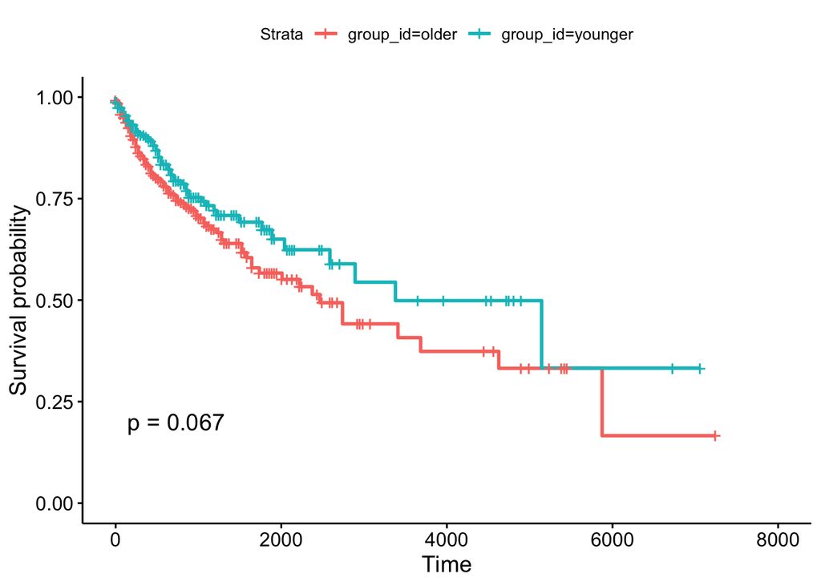

```r
sfit <- survfit(Surv(followup_time, followup_state)~group_id, data=survival_df)
ggsurvplot(sfit,data=survival_df,pval = T)
```

### Cohort-specific query

To get metadata from individuals with specific cohort, you need to use corresponding filters. Here we use TCGA-BRCA cohort from TCGA as an example and do the same survival analysis as above.

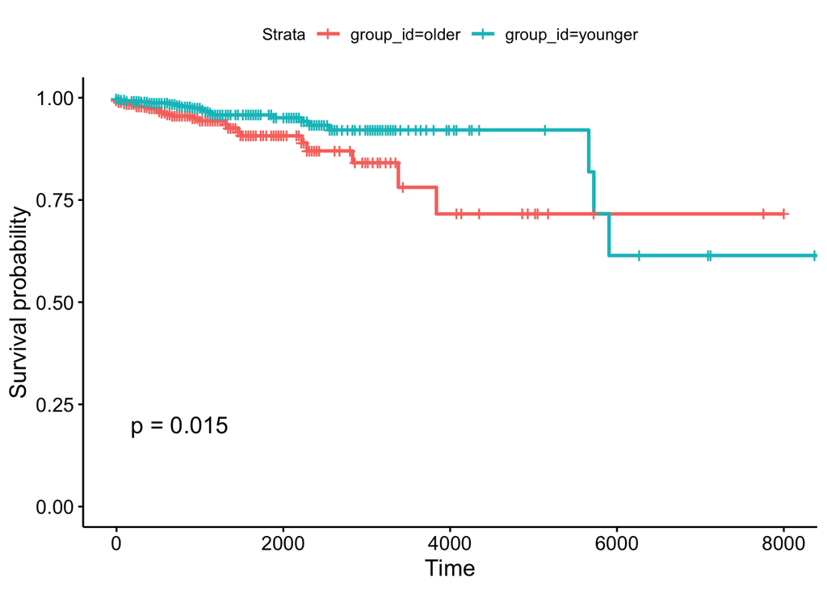

```r
# query
tcgabrcaind_young <- pgxLoader(type='individual',filters=c('pgx:TCGA.BRCA','age:<P60Y'))
tcgabrcaind_old <- pgxLoader(type='individual',filters=c('pgx:TCGA.BRCA','age:>=P60Y'))
# preprocess
tcgabrcaind_young_clean <- cleanData(tcgabrcaind_young)
tcgabrcaind_old_clean <- cleanData(tcgabrcaind_old)
# survival data construction
tcgabrcaind_clean <- rbind(tcgabrcaind_young_clean,tcgabrcaind_old_clean)
group_id <- rep(c('younger','older'),times=
                  c(dim(tcgabrcaind_young_clean)[1],dim(tcgabrcaind_old_clean)[1]))
followup_state <- as.numeric(tcgabrcaind_clean$index_disease_followup_state_label)
followup_time <- time_length(tcgabrcaind_clean$index_disease_followup_time,unit = 'days')
survival_df <- data.frame(group_id, followup_state, followup_state)
# fit
sfit <- survfit(Surv(followup_time, followup_state)~group_id, data=survival_df)
# visualise
ggsurvplot(sfit,data=survival_df,pval = T)
```